# Lecture #6: Working With R Studio I

Nicholas J. Gotelli

February 18, 2020

- `.Rmd` is Rstudio’s special blend of Markdown (a text rendering language)
- `.md` is the more generic Markdown file type. In RStudio, the intermediate `.md` files are not (in the default state) preserved.

### Languages

- `LaTeX` Typesetting language invented in the 1970s by computer programmer Donald Knuth for proper rendering of text and equations. Hundreds of commands. Precise, but somewhat complicated to use.
- `Markdown` Greatly simplified version of LaTeX with a small number of commands to master. Easy to use, text looks great.
- `yaml`[^1]. Header material for `.Rmd` files that can be changed manually or by selecting options.
- `R` Computer language for manipulating numbers, text, graphics, statistics.

### Using R-markdown

- pull up cheatsheet
- new `.Rmd` file

### Basic text formatting

- headers `#` to `######` *numbering from options
- text
- markup
  - italic `*<text>*`
  - bold-face `**<text>**`
  - subscript `~<text>~`
  - superscript `^<text>^`
  - strikethrough `~~<text>~~`
  - quotations `><text with no closing mark`

### Spacing, manual breaks, lines

- line spacing effects
- two extra spaces at the end of a line for a manual break
- lists
  - indented
  - numbered

### Links

- links `[linking text](website address)`
- footnotes[^2]
- images

```
![image link](website address)
```

### Tables

```
First Header  | Second Header
------------- | -------------
Content Cell  | Content Cell
Content Cell  | Content Cell
```

- also the `kable` package for later

```
{r, echo=TRUE,results='asis'}
library(knitr)
kable(head(iris))
```

```r
library(knitr)
kable(head(iris))
```

| Sepal.Length | Sepal.Width | Petal.Length | Petal.Width | Species |
| --- | --- | --- | --- | --- |
| 5.1 | 3.5 | 1.4 | 0.2 | setosa |
| 4.9 | 3.0 | 1.4 | 0.2 | setosa |
| 4.7 | 3.2 | 1.3 | 0.2 | setosa |
| 4.6 | 3.1 | 1.5 | 0.2 | setosa |
| 5.0 | 3.6 | 1.4 | 0.2 | setosa |
| 5.4 | 3.9 | 1.7 | 0.4 | setosa |

### Fencing

- in line fencing `to shade`
- in line R code for calculations 6.1415927
- simple fencing to set off large chunks of plain text

### Links

- links linking text
- footnotes[^3]
- images

```
![image link](website address)
```

### Tables

```
First Header  | Second Header
------------- | -------------
Content Cell  | Content Cell
Content Cell  | Content Cell
```

- also the `kable` package for later

```
{r, echo=TRUE,results='asis'}
library(knitr)
kable(head(iris))
```

```r
library(knitr)
kable(head(iris))
```

| Sepal.Length | Sepal.Width | Petal.Length | Petal.Width | Species |
| --- | --- | --- | --- | --- |
| 5.1 | 3.5 | 1.4 | 0.2 | setosa |
| 4.9 | 3.0 | 1.4 | 0.2 | setosa |
| 4.7 | 3.2 | 1.3 | 0.2 | setosa |
| 4.6 | 3.1 | 1.5 | 0.2 | setosa |
| 5.0 | 3.6 | 1.4 | 0.2 | setosa |
| 5.4 | 3.9 | 1.7 | 0.4 | setosa |

### Equations

- in-line `$`
- centered `$$`
- basic math and text spacing handled by LateX

```
$$y = a + b$$
```

$$y = a + b$$

#### Subcripts

```
$$H_0 = Z_{a + b}$$
```

$$H_0 = Z_{a + b}$$

#### Superscripts

```
$$S = cA^z$$
```

$$S = cA^z$$

- elements can be coupled and nested

$$S=cA^z_1 + z_{2 + x}$$

```
$$S=cA^z_1 + z_{2 + x}$$
```

#### Fractions and Greek Symbols

$$\alpha = \frac{\beta}{\delta + \gamma_x}$$

```
$$\alpha = \frac{\beta}{\delta + \gamma_x}$$
```

#### Summation signs

$$z = \sum_{i=1}^X{K}$$

```
$$z = \sum_{i=1}^X{K}$$
```

#### “Escaping” the special character in LaTeX

Use `\backslash`

```
$$\backslash \alpha \le b \backslash$$
```

$$\backslash \alpha \le b \backslash$$

#### Rendering plain text in a LaTex Equation

$$P(Occurrence Of Species A) = Z$$

```
$$P(Occurrence Of Species A) = Z$$
```

$$P(\mbox{Occurrence Of Species A}) = Z$$

```
$$P(\mbox{Occurrence Of Species A}) = Z$$
```

### R Code in Chunks

- `CTRL-ALT-I` inserts a new “chunk” of R code

```r
# Use comments extensively in ALL of your coding!
Pred <- seq(1,10)     # make a vector of integers from 1 to 10
Res <- runif(10)      # generate 10 draws from a random uniform (0,1) distribution

# print the random numbers
print(Res)
```

```
##  [1] 0.0933158582 0.0053487171 0.0941875302
##  [4] 0.0003674456 0.7462661173 0.7927605622
##  [7] 0.9405337111 0.4440057806 0.3929501660
## [10] 0.9859461512
```

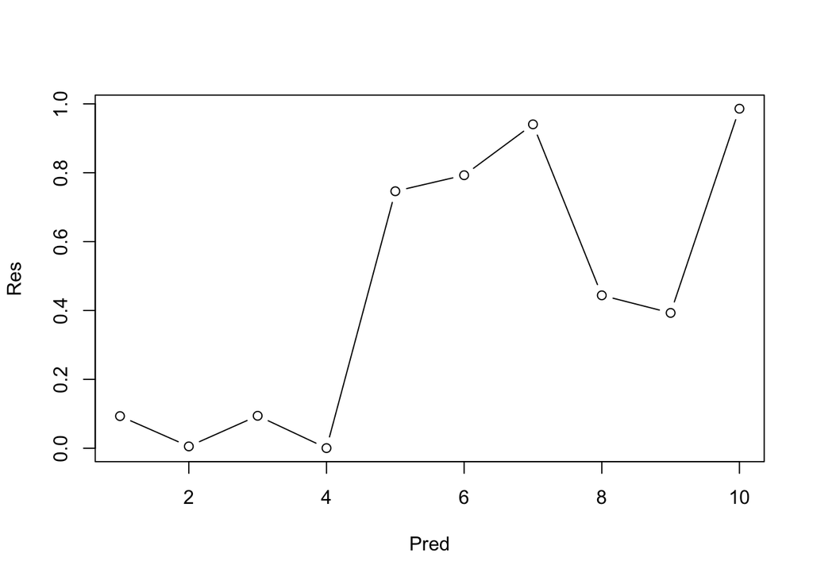

```r
# plot the graph
plot(x=Pred,y=Res,type="b")
```

### Using chunk options `echo` and `eval` to control printing of code and output

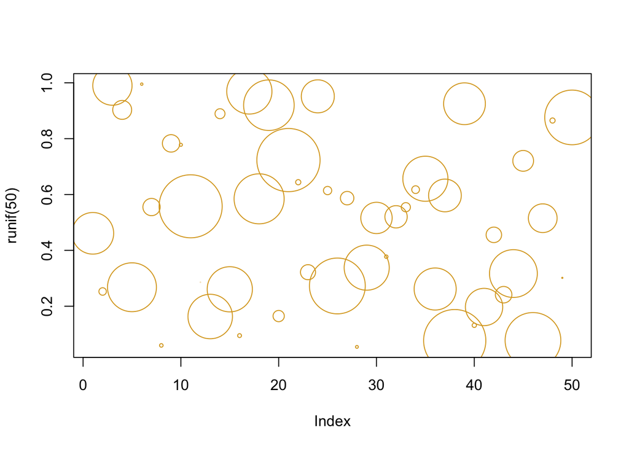

```r
plot(runif(50),cex=10*runif(50),col="goldenrod")
```

```r
print(rnorm(n=10, mean=10, sd=2))
```

```
##  [1]  6.277952  8.865220  7.656927 10.875649
##  [5] 11.601855  7.086990  9.879044 11.761556
##  [9] 14.885561 12.402202
```

### Writing R scripts

- new script
- code executes and prints in console
- graphs in output window
- `CTRL - ENTER` to run a single line of code
- `CTRL - SHIFT - ENTER` to source the entire script
- code to illustrate:

```r
# First comment to explain what this program is doing.
# Be expansive and describe it in great detail. This may seem trivial, but will become increasingly important as you create complex programs.
# Simple script to examine the distribution of the product of two uniform variables
# Make sure it is readable. Use complete sentences, not cryptic phrases.
# 6 September 2018
# NJG

# Preliminaries
library(ggplot2)
set.seed(100)
library(TeachingDemos) # use this to set the random number seed from a character string
char2seed("green tea")
char2seed("green tea",set=FALSE)
```

```
## [1] 7023541
```

```r
#

# Global variables
nRep <- 10000

# Create or read in data
ranVar1 <- rnorm(nRep)
# print(ranVar1)
head(ranVar1)
```

```
## [1] -0.67595800  0.07142749 -0.13803318
## [4] -0.99300667 -1.17181879  0.51340840
```

```r
tail(ranVar1)
```

```
## [1]  0.35209291 -0.11819204  0.57509922
## [4] -0.05122504 -1.98879289 -1.04776740
```

[output not shown]

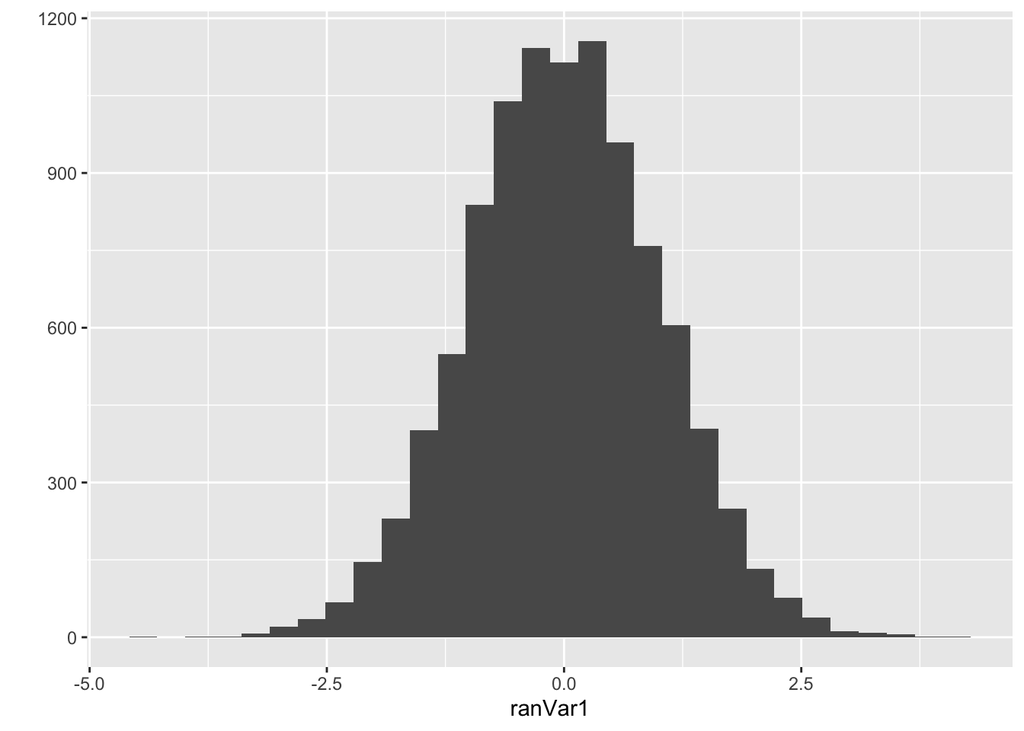

```r
ranVar2 <- rnorm(nRep)


# visualize data
qplot(x=ranVar1)
```

```r
# create product vector
ranProd <- ranVar1*ranVar2
length(ranProd)
```

```
## [1] 10000
```

```r
str(ranProd)
```

```
##  num [1:10000] -1.3151 0.0117 0.1435 2.2531 -0.9411 ...
```

```r
head(ranProd)
```

```
## [1] -1.31510790  0.01168855  0.14346105
## [4]  2.25309300 -0.94114160  0.13995337
```

```r
# do other stuff..
```

### Converting `.R` files to `.html` (creating an R notebook)

- use notebook script
- roxygen comments ``#`

### `Purling` to strip and consolidate R chunks from a Markdown file

- commands executed from console

```
library(knitr)
purl("FileName.Rmd")
```

These commands will create a file `FileName.R` that has all of the R code and none of the markdown text. R comments are still retained.

## Bonus: A Cool New Markdown Editor!

- Demo of `Typora` a WYSIWYG text editor at https://typora.io/

## Working with LaTeX

This uses another Rstudiotemplate for a `sweave` document of the type `<filename>.Rnw`. Here is some code for a minimal LaTeX document illustrating how to use the kind of formatting we used in markdown:

````
\documentclass{article}

\begin{document}

Plain text is much the same, even in \LaTeX.

\section{First header}
\subsection{Second header}
\subsubsection{Third header}

Here is \textbf{bold face}\\
Here is \textit{italic text}\\
Here is \texttt{plain text}.

``Use double back ticks and single quotes to start and finish a quotation.''

\begin{itemize}
  \item first bullet
  \item second bullet
  \item third bullet
\end{itemize}

\begin{enumerate}
  \item number one
  \item number two
  \item number three
\end{enumerate}

\begin{verbatim}
This is more convenient for a larger block of verbatim text.
This is equivalent to the ``` plain fencing ``` from markdown.
\end{verbatim}

\begin{quote}
Again, works better for a much more extensive paragraph of quoted text such as this.
\end{quote}

<<echo=TRUE>>=
x <- runif(10)
y <- runif(10)
plot(x,y)
@

% In contrast to R and shell scripts, the character for a comment in LaTeX is the % sign.

Use the ``escape'' sequence to show a percentage sign like this: \%.
\end{document}
````

Go to Overleaf (https://www.overleaf.com/) for an on-line LaTeX editor with great templates and LaTeX documentation.

Show use of templates for a letterhead with signature, and for building slides in Beamer.

If packages are missing (“no `.sty` file”), try the following command from the `tinytex` package to install them: `tinytex::tlmgr_install("packagename")`.

[^1]: Originally “Yet Another Markdown Language”, but more recently “YAML Ain’t no Markdown Language”, which is a self-referencing acronym
[^2]: Footnoted text, consecutively at bottom of page
[^3]: Footnoted text, consecutively at bottom of page